# Dataquset Guided Project #2: Analyzing Forest Fire Data

# Analyzing Forest Fire Data

```r
rm(list=ls())
```

```r
library(tidyverse)
```

```r
library(readr)
library(ggplot2)
```

```r
forest <- as_tibble(read_csv("forestfires.csv"))
```

Forest fires can create ecological problems and endanger human lives and property. Understanding when they occur and what causes them is important for managing them. The data we’ll be working with in this guided project is associated with a scientific research paper on predicting the occurrence of forest fires in Portugal using modeling techniques.

Here are descriptions of the variables in the data set and the range of values for each taken from the paper:

- X: X-axis spatial coordinate within the Montesinho park map: 1 to 9
- Y: Y-axis spatial coordinate within the Montesinho park map: 2 to 9
- month: Month of the year: ‘jan’ to ‘dec’
- day: Day of the week: ‘mon’ to ‘sun’
- FFMC: Fine Fuel Moisture Code index from the FWI system: 18.7 to 96.20
- DMC: Duff Moisture Code index from the FWI system: 1.1 to 291.3
- DC: Drought Code index from the FWI system: 7.9 to 860.6
- ISI: Initial Spread Index from the FWI system: 0.0 to 56.10
- temp: Temperature in Celsius degrees: 2.2 to 33.30
- RH: Relative humidity in percentage: 15.0 to 100
- wind: Wind speed in km/h: 0.40 to 9.40
- rain: Outside rain in mm/m2 : 0.0 to 6.4
- area: The burned area of the forest (in ha): 0.00 to 1090.84 #

```r
#Cleaning the data and transforming the variables 'Month' and 'day' as categorical variables.

forest %>%
  pull(month) %>%
  unique
```

```
##  [1] "mar" "oct" "aug" "sep" "apr" "jun" "jul" "feb" "jan" "dec" "may" "nov"
```

```r
forest %>%
  pull(day) %>%
  unique
```

```
## [1] "fri" "tue" "sat" "sun" "mon" "wed" "thu"
```

```r
month_order <- c("jan", "feb", "mar", "apr", "may", "jun", "jul", "aug", "sep", "oct", "nov", "dec")
day_Order <- c("mon", "tue", "wed", "thu", "fri", "sat", "sun")

forest <- forest %>%
  mutate(month = factor(month, levels = month_order),
         day = factor(day, levels = day_Order))
```

We’ve seen two variables concerning time: month and day. These two columns allow us to ask:

- Which months do forest fires happen the most?
- Which days of the week do forest fires happen the most?

The problem is that the data in its current form describes individual fires. It would be easier to plot the data if it is grouped up by month or day of the year before going to ggplot. We can think of month and day as grouping variables that we can use with the *group_by()* and *summarize()* functions. This duo of functions will help us create the new tibbles we need to plot.

```r
# A tibble with fires by month

forest_month <- forest %>%
  group_by(month) %>%
  summarize(fire_total = n())

forest_month
```

```
## # A tibble: 12 x 2
##    month fire_total
##  * <fct>      <int>
##  1 jan            2
##  2 feb           20
##  3 mar           54
##  4 apr            9
##  5 may            2
##  6 jun           17
##  7 jul           32
##  8 aug          184
##  9 sep          172
## 10 oct           15
## 11 nov            1
## 12 dec            9
```

```r
# A tibble with fires by day

forest_day <- forest %>%
  group_by(day) %>%
  summarize(fire_total = n())

forest_day
```

```
## # A tibble: 7 x 2
##   day   fire_total
## * <fct>      <int>
## 1 mon           74
## 2 tue           64
## 3 wed           54
## 4 thu           61
## 5 fri           85
## 6 sat           84
## 7 sun           95
```

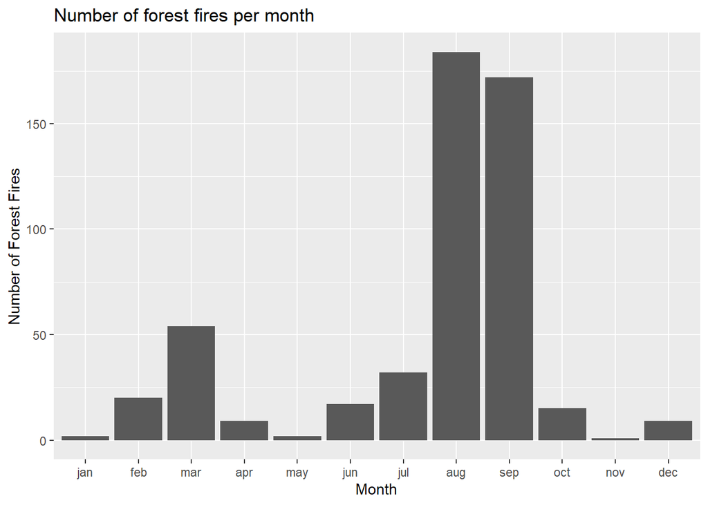

```r
#Visualizing the data per month

forest_month %>%
  ggplot(aes(x = month, y = fire_total)) +
  geom_col() +
  labs(title = "Number of forest fires per month",
       x = "Month",
       y = "Number of Forest Fires")
```

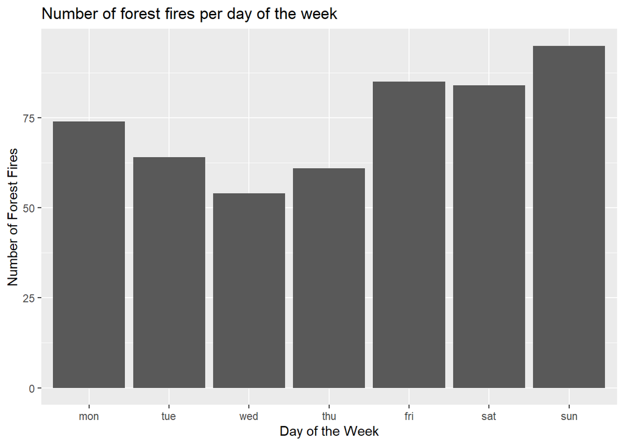

```r
#Visualizing the data per day of the week

forest_day %>%
  ggplot(aes(x = day, y = fire_total)) +
  geom_col() +
  labs(title = "Number of forest fires per day of the week",
       x = "Day of the Week",
       y = "Number of Forest Fires")
```

By the data we can easily see that the number of fires spike enormously during the months of August ad September. There is also a smaller spike during March. Regarding the days of the week, although there is only a small variance, it happens more frequent during the weekend days (from Friday to Sunday).

To explore the temporal patterns of forest fire occurrence the bar charts reveal, we should look more closely at how the variables that relate to forest fires vary by month and by day of the week. We should see how each of the other variables in the dataset relates to month. We’ll exclude day for now since it’s really the months that can vary a lot between seasons.

We have the following columns:

- FFMC
- DMC
- DC
- ISI
- temp
- RH
- wind
- rain

Let’s create some visualizations that look at the relationship between month and each of the columns above. Our goal is to check if any of the variables have values that stand out during August and September, which we’ve previously confirmed sees a lot of fires.

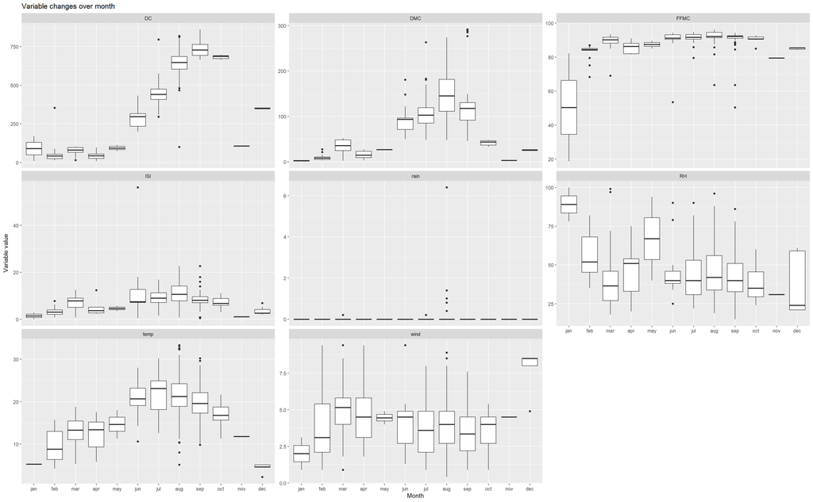

```r
forest_fires_long <- forest %>%
  pivot_longer(
    cols = c("FFMC", "DMC", "DC",
             "ISI", "temp", "RH",
             "wind", "rain"),
    names_to = "data_col",
    values_to = "value"
  )

forest_fires_long %>%
  ggplot(aes(x = month, y = value)) +
  geom_boxplot() +
  facet_wrap(vars(data_col), scale = "free_y") +
  labs(
    title = "Variable changes over month",
    x = "Month",
    y = "Variable value"
  )
```

So far, we’ve only looked at the relationship between the variables in the data and the frequency of forest fires. Fires can also range in intensity too, so it might be useful to know what factors influence this as well.

Looking at the data immediately though, there is no variable that describes just “severity”. Many times in analysis, we’ll be interested in a variable, but simply won’t have the data for it. In these cases, we often have to look at *proxies*, or a kind of “representation” of severity. In this data set, the *area* variable contains data on the number of hectares of forest that burned during the forest fire. We’ll use this variable as an indicator of the severity of the fire. The idea behind using area as a proxy is that worse fires will result in a larger burned area. Of course, this won’t be true in all cases, but it is a reasonable assumption to make.

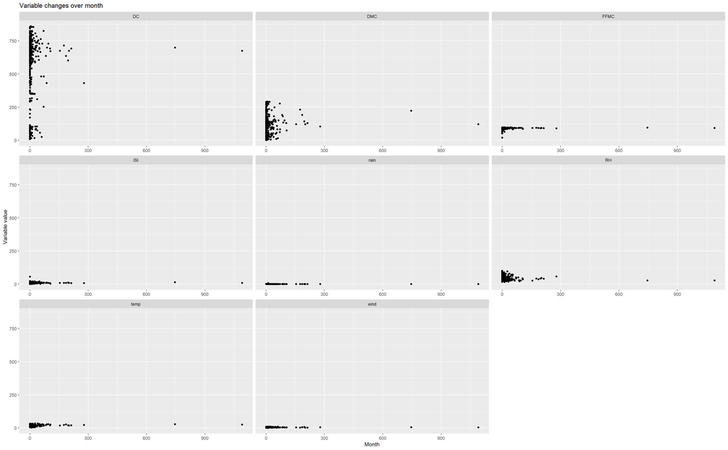

```r
# Visualizing the relationship between the variables with the area

forest_fires_long %>%
  ggplot(aes(x = area, y = value)) +
  geom_point() +
  facet_wrap(vars(data_col), scale = "free_x") +
  labs(
    title = "Variable changes over month",
    x = "Month",
    y = "Variable value"
  )
```